# Data Science Specialization - Text Prediction App

Stefano Masneri  
October 6th, 2016

### Introduction

The objective of the Capstone project is to build a complete data product which performs text prediction. In particular, the capstone required us to do:

- [Data](https://d396qusza40orc.cloudfront.net/dsscapstone/dataset/Coursera-SwiftKey.zip) acquisition
- Data exploration and preprocessing
- Model creation
- App deployment

### Language model

The language model was created extracting the frequencies of words, 2-, 3- and 4-grams. These are the steps implemented in the creation of the model:

- Use 90% of the data for training, 10% for testing
- Fix a dictionary of words after removing unigrams appearing less then *50* times
- Replace Out-of-Dictionary words in 2-, 3- and 4-grams with the special word *<UNK>*
- Create sparse arrays for N-grams. Each dimension contain the words in the dictionary.
- Prediction implemented as a lookup in the array (*fixing* N-1 dimensions and extracting the higher values in the remaining vector)

### Accuracy

The model has been evaluated by selecting a subset of the corpus and trying to predict every word.

- The top-3 accuracy is *53%* and the top-5 accuracy is *64%*
- Using special words for start of sentence and unknown words gives a smaller increse of accuracy (*~3.5%*)
- The model implements *stupid backoff*.
- Good-Turing backoff was tested but didn't give any improvements in accuracy

## Shiny Application

A shiny application demonstrating the model is available [here](http://stocastico.shinyapps.com/Text_Prediction).

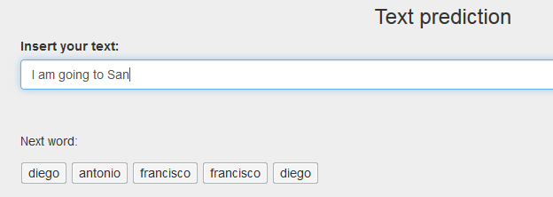